# Hit Probability Model Build

Judah Axelrod

Setup Import dataset; load tidyverse, glmnet, mgcv, and caret libraries; summarize data

```
##      GameId         BallparkId      GameEventId          GameTime
##  Min.   :344124   Min.   :  1.00   Min.   :226194204   Length:115137
##  1st Qu.:344733   1st Qu.:  8.00   1st Qu.:226527203   Class1:hms
##  Median :345343   Median : 17.00   Median :226767607   Class2:difftime
##  Mean   :345407   Mean   : 35.28   Mean   :243438821   Mode  :numeric
##  3rd Qu.:345941   3rd Qu.: 43.00   3rd Qu.:277249320
##  Max.   :439376   Max.   :387.00   Max.   :305709960
##
##      Season        AtBatId          TrackManUid           BatterId
##  Min.   :2018   Min.   : 78636823   Length:115137      Min.   :  2525
##  1st Qu.:2018   1st Qu.: 78716304   Class :character   1st Qu.: 62786
##  Median :2018   Median : 78774056   Mode  :character   Median : 94607
##  Mean   :2018   Mean   : 85195036                      Mean   : 78489
##  3rd Qu.:2018   3rd Qu.: 98744462                      3rd Qu.:102053
##  Max.   :2018   Max.   :106503987                      Max.   :127306
##
##  BatterHitting      BatterPositionId batterTimesFaced
##  Length:115137      Min.   : 1.000   Min.   :1.000
##  Class :character   1st Qu.: 4.000   1st Qu.:1.000
##  Mode  :character   Median : 6.000   Median :1.000
##                     Mean   : 5.909   Mean   :1.549
##                     3rd Qu.: 8.000   3rd Qu.:2.000
##                     Max.   :14.000   Max.   :5.000
##                     NA's   :170
##  cumulativeBattersFaced    PinchHit   PitcherId      PitcherThrowing
##  Min.   : 1.000         Min.   :0   Min.   :  2525   Length:115137
##  1st Qu.: 3.000         1st Qu.:0   1st Qu.: 63615   Class :character
##  Median : 7.000         Median :0   Median : 95263   Mode  :character
##  Mean   : 9.073         Mean   :0   Mean   : 80616
##  3rd Qu.:15.000         3rd Qu.:0   3rd Qu.:103072
##  Max.   :36.000         Max.   :0   Max.   :127306
##
##    CatcherId        HomeTeamId      AwayTeamId     PitchType
##  Min.   : 16352   Min.   : 6.00   Min.   : 6.00   Length:115137
##  1st Qu.: 41474   1st Qu.:13.00   1st Qu.:13.00   Class :character
##  Median : 76147   Median :20.00   Median :20.00   Mode  :character
##  Mean   : 70009   Mean   :20.44   Mean   :20.47
##  3rd Qu.: 98320   3rd Qu.:28.00   3rd Qu.:28.00
##  Max.   :111662   Max.   :35.00   Max.   :35.00
##
```

[output cut: 65 more lines]

```
##  Min.   :67.00   Min.   :  9.284   Min.   :-89.037   Min.   :-171.3830
##  1st Qu.:73.00   1st Qu.: 80.200   1st Qu.: -4.861   1st Qu.: -19.5872
##  Median :75.00   Median : 91.249   Median : 12.388   Median :  -1.4399
##  Mean   :74.74   Mean   : 88.637   Mean   : 11.406   Mean   :  -0.9092
##  3rd Qu.:76.00   3rd Qu.: 99.174   3rd Qu.: 28.370   3rd Qu.:  17.5383
##  Max.   :82.00   Max.   :121.704   Max.   : 89.752   Max.   : 177.7580
##
##    Direction
##  Min.   :-169.924
##  1st Qu.: -17.851
##  Median :  -1.843
##  Mean   :  -1.408
##  3rd Qu.:  14.774
##  Max.   : 163.799
##
```

I take a few steps to clean and manipulate the data into a form suitable for modeling. (1) Create a “hit_flag” any time a batted ball in play results in a hit or fielding error to serve as my binary response variable. (2) Create interaction terms for “Bearing” based on pitcher and batter handedness. This is because the ball’s landing position angle with home plate should depend heavily on lefty/righty matchups, especially on the hitter side. (3) Keep only a subset of all fields provided in Trackman data. These will serve as my “candidate regressors” whose predictive relevance I will test when in the feature selection stage. As a note, because spin rate is missing for 1,676 observations, I choose to omit it from consideration.

```r
trackman18_rel_vars <- trackman18 %>%
  mutate(hit_flag = ifelse(h1b == 1 | h2b == 1 | h3b == 1 | hr == 1 | fieldingError == 1, 1, 0),
         count = paste0(Balls,"-",Strikes),
         PitcherRHP = ifelse(PitcherThrowing == "R",1,0),
         RHP.Bearing = PitcherRHP*Bearing,
         BatterRHH = ifelse(BatterHitting == "R",1,0),
         RHH.Bearing = BatterRHH*Bearing) %>%
  select(-c(SpinRate,BatterId,PitcherId,CatcherId,BallparkId,GameId,GameEventId,Season,GameTime,AtBatId,TrackManUid,BatterPositionId,HomeTeamId,AwayTeamId,
            calledStrike,swing,swingStrike,foul,inPlay,h1b,h2b,h3b,hr,hbp,fieldingError,inPlayOut,Balls,Strikes)) %>%
  select(hit_flag, everything())
```

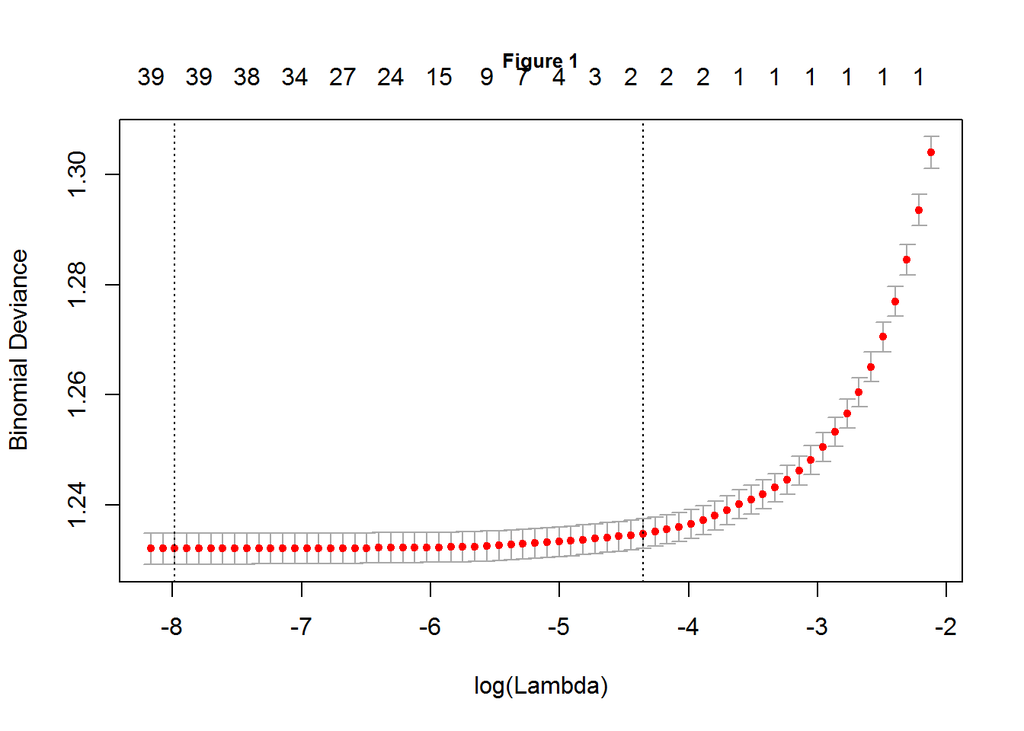

```r
x <- model.matrix(hit_flag~.,trackman18_rel_vars)[,-1]
y <- trackman18_rel_vars$hit_flag
set.seed(2000)
train <- sample(1:nrow(x),0.5*nrow(x))

cv_feature <- cv.glmnet(x[train,], y[train], family = "binomial", alpha = 1)
plot(cv_feature, main = "Figure 1", cex.main = 0.8)
```

```r
bestlambda <- cv_feature$lambda.min
bestlambda
```

```
## [1] 0.0003414691
```

```r
grid <- 10^seq(10, -2, length = 100)
lasso <- glmnet(x[train,],y[train],alpha = 1, lambda = grid, family = "binomial")
predict(lasso, type = "coefficients", s=bestlambda)
```

```
## 52 x 1 sparse Matrix of class "dgCMatrix"
##                                    1
## (Intercept)            -4.083084e+00
## BatterHittingR          .
## batterTimesFaced        .
## cumulativeBattersFaced  .
## PinchHit                .
## PitcherThrowingR        .
## PitchTypeCH             .
## PitchTypeCT             .
## PitchTypeFB             .
## PitchTypeKN             .
## PitchTypeSI             .
## PitchTypeSL             .
## PitchTypeSP             .
## Outs                    .
## Inning                  .
## InningTop               .
## PlateAppearance         .
## PitchOfPA               .
## Runners_on              .
## HorzBreak               .
## VertBreak               .
## StartSpeed              .
## Px                      .
## Pz                      .
## RelHeight               .
## RelSide                 .
## Extension               .
## VertRelAngle            .
## HorzRelAngle            .
## SpinAxis                .
## BatterHeight            .
## PitcherHeight           .
## ExitSpeed               3.881024e-02
## Angle                  -1.676286e-05
## Bearing                 .
## Direction               .
## count0-1                .
## count0-2                .
## count1-0                .
## count1-1                .
## count1-2                .
## count2-0                .
## count2-1                .
## count2-2                .
## count3-0                .
## count3-1                .
## count3-2                .
## count4-2                .
## PitcherRHP              .
## RHP.Bearing             .
## BatterRHH               .
## RHH.Bearing            -4.005153e-03
```

To evaluate my baseline logistic regression model using the variables selected above, I now perform 10-fold cross validation over the entire sample. We can see that the Accuracy (proportion of correctly identified instances) is about 0.69 and the Kappa (accuracy corrected for randomness) is about 0.21.

```r
xBA.glm <- glm(hit_flag ~ ExitSpeed + Angle + Bearing + BatterRHH + RHH.Bearing, family = binomial, data = trackman18_rel_vars)
summary(xBA.glm)
```

```
##
## Call:
## glm(formula = hit_flag ~ ExitSpeed + Angle + Bearing + BatterRHH +
##     RHH.Bearing, family = binomial, data = trackman18_rel_vars)
##
## Deviance Residuals:
##     Min       1Q   Median       3Q      Max
## -1.5909  -0.9634  -0.7262   1.1939   2.8246
##
## Coefficients:
##               Estimate Std. Error z value Pr(>|z|)
## (Intercept) -4.5881129  0.0500276 -91.712  < 2e-16 ***
## ExitSpeed    0.0446098  0.0005433  82.108  < 2e-16 ***
## Angle       -0.0019963  0.0002775  -7.193 6.32e-13 ***
## Bearing      0.0008964  0.0004435   2.021   0.0433 *
## BatterRHH   -0.0159105  0.0132974  -1.197   0.2315
## RHH.Bearing -0.0066759  0.0005914 -11.288  < 2e-16 ***
## ---
## Signif. codes:  0 '***' 0.001 '**' 0.01 '*' 0.05 '.' 0.1 ' ' 1
##
## (Dispersion parameter for binomial family taken to be 1)
##
##     Null deviance: 150114  on 115136  degrees of freedom
## Residual deviance: 141474  on 115131  degrees of freedom
## AIC: 141486
##
## Number of Fisher Scoring iterations: 4
```

```r
baseline_train_control <- trainControl(method = "cv", number = 10)
baseline_model <-train(as.factor(hit_flag) ~ BatterRHH + ExitSpeed + Angle + Bearing,
              data = trackman18_rel_vars,
              trControl = baseline_train_control,
              method = "glm",
              family = binomial())
baseline_model$results
```

```
##   parameter  Accuracy     Kappa  AccuracySD     KappaSD
## 1      none 0.6862954 0.2081174 0.001802172 0.005956898
```

```r
baseline_model$finalModel
```

```
##
## Call:  NULL
##
## Coefficients:
## (Intercept)    BatterRHH    ExitSpeed        Angle      Bearing
##   -4.642625    -0.018058     0.045485    -0.002690    -0.002957
##
## Degrees of Freedom: 115136 Total (i.e. Null);  115132 Residual
## Null Deviance:       150100
## Residual Deviance: 141600    AIC: 141600
```

It stands to reason that the relationship between these predictors and the probability of a hit would be nonlinear. After all, only launch angles within a certain “barrel zone” are likely to result in hits, while the probability falls anywhere above and below this region. The same can be said of Bearing, due to positioning of the fielders and the spots on the field in which batted balls would result in a hit. Therefore, my preferred modeling technique is a generalized additive model (GAM) which applies smoothing to the specified regressors in order to account for these nonlinear relationships.

Again, I use the selected features above and build my GAM over the 50% training sample. Variables that I intuit to be nonlinear are placed inside spline-based smoothing functions. I account for the interaction effect found to be significant by specifying a smoothing function for Bearing, split out by both LHHs and RHHs. The plots below depict the smoothing curves applied by my GAM.

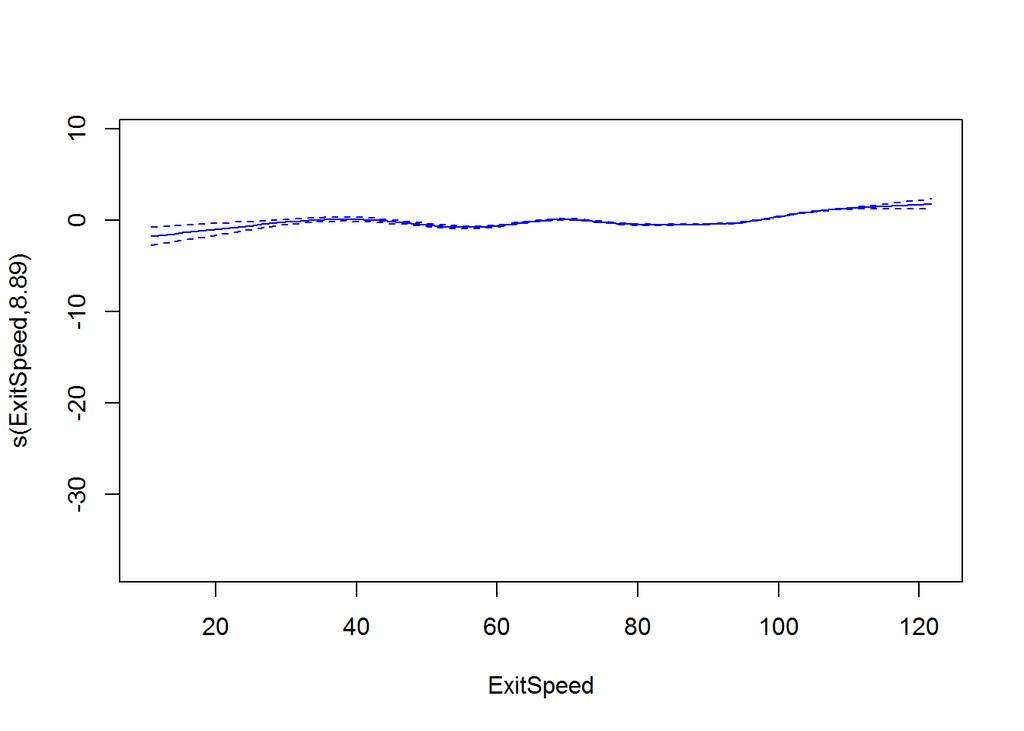

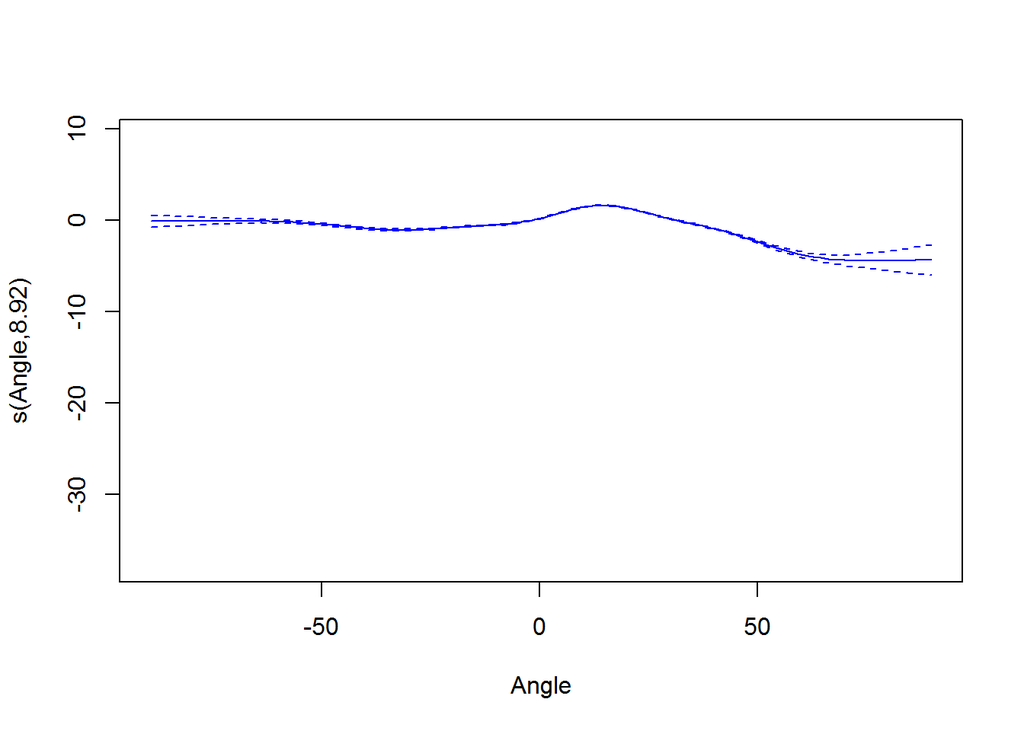

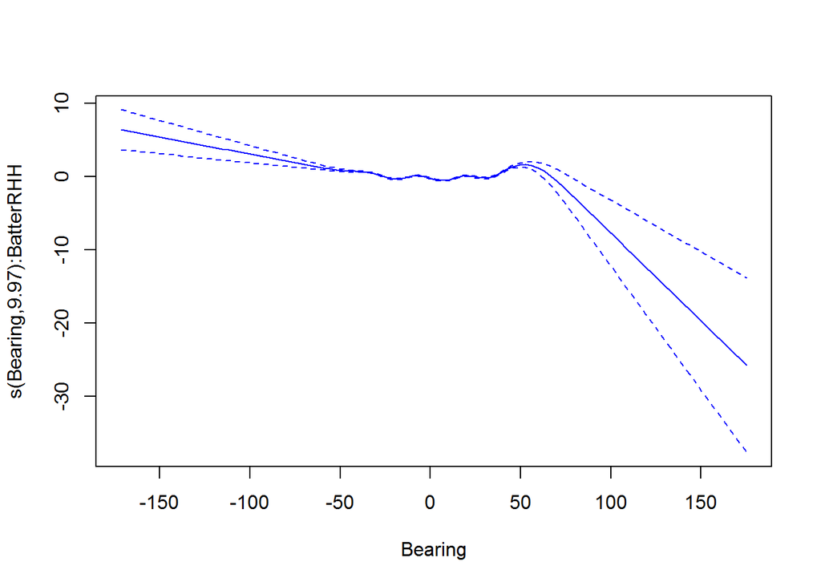

```r
trackman18_sample  <- trackman18_rel_vars[train,]
xBA.gam <- gam(hit_flag ~ BatterRHH + s(ExitSpeed) + s(Angle) + s(Bearing, by = BatterRHH), family = binomial, data = trackman18_sample)
plot.gam(xBA.gam,se=TRUE,col="blue")
```

Finally, I perform 10-fold cross validation on my GAM to evaluate performance over the entirety of the sample.

```r
train_control <- trainControl(method = "cv", number = 10)
model <-train(as.factor(hit_flag) ~ BatterRHH + ExitSpeed + Angle + Bearing,
              data = trackman18_rel_vars,
              trControl = train_control,
              method = "gam",
              family = binomial())
summary(model)
```

```
##
## Family: binomial
## Link function: logit
##
## Formula:
## .outcome ~ BatterRHH + s(ExitSpeed) + s(Bearing) + s(Angle)
##
## Parametric coefficients:
##             Estimate Std. Error z value Pr(>|z|)
## (Intercept) -0.88897    0.01348 -65.946   <2e-16 ***
## BatterRHH   -0.00464    0.01506  -0.308    0.758
## ---
## Signif. codes:  0 '***' 0.001 '**' 0.01 '*' 0.05 '.' 0.1 ' ' 1
##
## Approximate significance of smooth terms:
##                edf Ref.df Chi.sq p-value
## s(ExitSpeed) 8.925      9   5725  <2e-16 ***
## s(Bearing)   8.944      9   1851  <2e-16 ***
## s(Angle)     7.972      9  14805  <2e-16 ***
## ---
## Signif. codes:  0 '***' 0.001 '**' 0.01 '*' 0.05 '.' 0.1 ' ' 1
##
## R-sq.(adj) =   0.28   Deviance explained = 23.4%
## UBRE = -0.0011223  Scale est. = 1         n = 115137
```

```r
model$results
```

```
##   select method  Accuracy     Kappa  AccuracySD     KappaSD
## 1  FALSE GCV.Cp 0.7583314 0.4590818 0.002719653 0.006249895
## 2   TRUE GCV.Cp 0.7585573 0.4595326 0.002487022 0.005821178
```

Here, the Accuracy (0.76) and Kappa (0.46) are both significantly higher than was the case for the GLM. This means that, as expected, accounting for nonlinear relationships in the GAM improved the model’s predictive power.

Finally, I run the preferred GAM over the entirety of the Trackman data. To give an example of why building this hit probability model can prove useful, I map the GAM predictions to their original observations. I then present the following visualizations to underscore the findings of my model:

1. I map the exit velocities and launch angles that corresponded to xBA > 0.500 to show that my model aligns well with Statcast’s definitions of “Hard Hit” (95+ mph) and “Sweet Spot” (8-32°) batted balls that are likeliest to result in hits.
2. Using the definition of “Barrels” from (1), I then present an xBA heat map of the strike zone by the 4 most common pitch types and whether or not a player barrelled a batted ball. As we can see below, pitches in comparable areas of the zone are far likelier to be hits if they are barrelled balls, regardless of pitch.

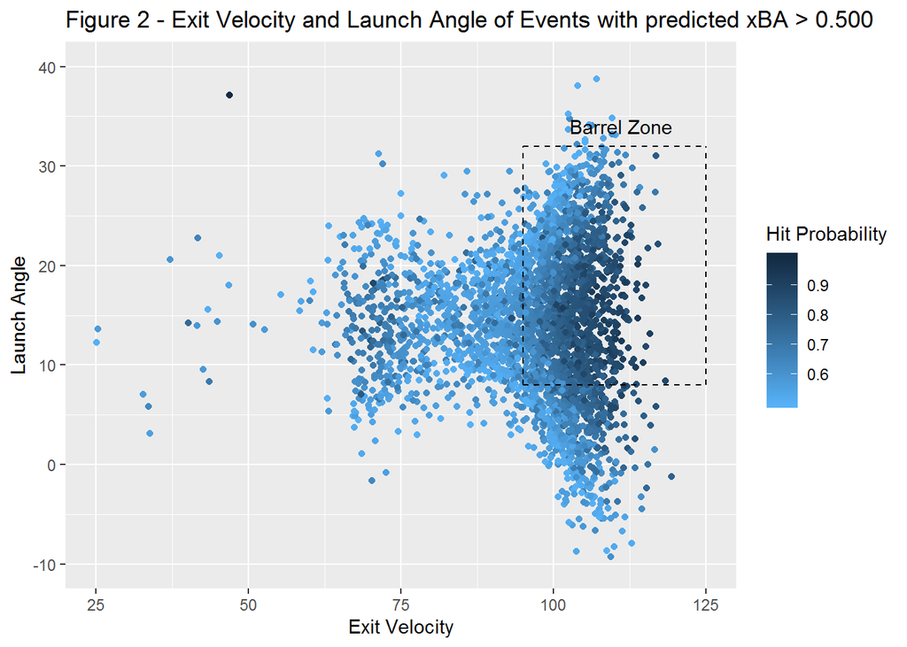

```r
xBA.gam.full <- gam(hit_flag ~ BatterRHH + s(ExitSpeed) + s(Angle) + s(Bearing, by = BatterRHH), family = binomial, data = trackman18_rel_vars)


predictions <- as.data.frame(predict(xBA.gam.full, trackman18_rel_vars, type = "response"))
trackman18_pred <- cbind(trackman18_rel_vars,predictions) %>%
  filter(PitchType %in% c("FB","SL","CB","CH")) %>%
  rename(predictions = `predict(xBA.gam.full, trackman18_rel_vars, type = \"response\")`) %>%
  mutate(barrel_flag = ifelse(ExitSpeed >= 95 & Angle <= 32 & Angle >=8, "Barrel", "Non-Barrel"))


ggplot(filter(sample_n(trackman18_pred,10000),predictions>0.5),aes(x=ExitSpeed,y=Angle,color=predictions)) + geom_point() + labs(color = "Hit Probability") + scale_color_gradient(low = "#56B1F7", high = "#132B43") + scale_x_continuous("Exit Velocity",limits = c(25,125)) +
  scale_y_continuous("Launch Angle",limits = c(-10,40)) +       geom_segment(aes(x=95,y=8,xend=125,yend=8),color="black",linetype="dashed") +
  geom_segment(aes(x=95,y=8,xend=95,yend=32),color="black",linetype="dashed") +
  geom_segment(aes(x=95,y=32,xend=125,yend=32),color="black",linetype="dashed") +
  geom_segment(aes(x=125,y=8,xend=125,yend=32),color="black",linetype="dashed") +
  annotate("text",111,34,label = "Barrel Zone") +
  ggtitle("Figure 2 - Exit Velocity and Launch Angle of Events with predicted xBA > 0.500")
```

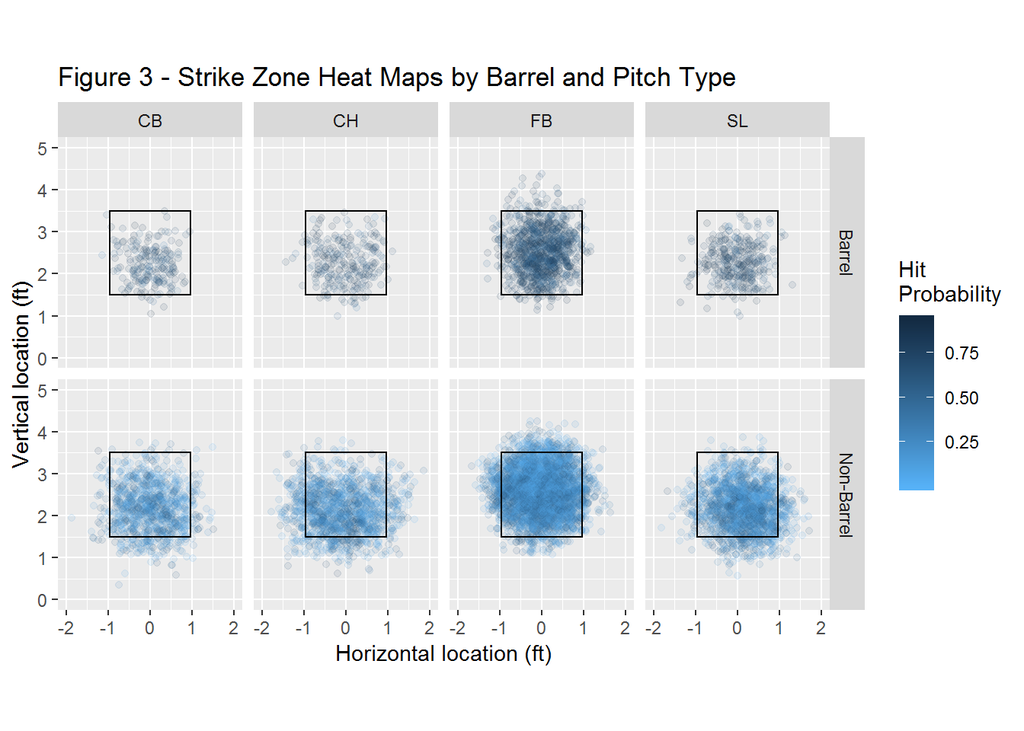

```r
ggplot(sample_n(trackman18_pred,10000)) +
  coord_equal() + scale_x_continuous("Horizontal location (ft)", limits = c(-2,2)) +
  scale_y_continuous("Vertical location (ft)", limits = c(0,5)) +
  geom_point(aes(x = Px, y = Pz, color = predictions), alpha = 0.1) +
  scale_color_gradient("Hit \nProbability", low = "#56B1F7", high = "#132B43") +
  geom_rect(xmin = -0.96, xmax = 0.96, ymin = 1.5, ymax = 3.5, color = "black", fill = NA, alpha = 0.01)+
  facet_grid(barrel_flag~PitchType) +
    ggtitle("Figure 3 - Strike Zone Heat Maps by Barrel and Pitch Type")
```